# **Understand the 'Meta' in Valorant**

#### Leo Fafoutis MSML602

# Introduction

Valorant is a 5v5 tactical first-person shooter from Riot Games. It involves a variety of different ‘agents’ (characters to choose from) and has two phases, attack and defend. In both phases, players will try to either eliminate the enemy team, or plant/defuse the ‘spike’ to win a round. Each agent has a unique set of abilities with only 1 player per team being able to select each.

In most competitive esports, there is a term called ‘meta’. This defines the best selection of agents to play during a certain era of the game based on how strong the agent's abilities are. However, there are many cases of teams winning with ‘off-meta’ team compositions or perceived metas being different across certain regions of play.

In this tutorial, we will try to gain a better understanding of the data science pipeline and try to answer the question, ‘what is meta, and does it exist?’. [Dataset](https://www.kaggle.com/datasets/visualize25/valorant-pro-matches-full-data)

## Data Collection

To begin, we start with loading our data using [Pandas](https://pandas.pydata.org/pandas-docs/stable/). We can view the tables from our sqlite file and print the first entry from each.

```python
import sqlite3
import pandas as pd
import seaborn as sns
import matplotlib.pyplot as plt

# Open the connection to the sqlite file in the data folder
conn = sqlite3.connect('data\\valorant.sqlite')

# Set each of the different tables to a unique pandas dataframe
matches = pd.read_sql_query("SELECT * FROM Matches", conn)
games = pd.read_sql_query("SELECT * FROM Games", conn)
game_rounds = pd.read_sql_query("SELECT * FROM Game_Rounds", conn)
game_scoreboard = pd.read_sql_query("SELECT * FROM Game_Scoreboard", conn)

# Display the entire first entry of each table, then close the connection to the sqlite file
print("Matches Table")
display(matches.head(1))

print("\nGames Table")
display(games.head(1))

print("\nGame_Rounds Table")
display(game_rounds.head(1))

print("\nGame_Scoreboard Table")
display(game_scoreboard.head(1))

conn.close()

# Allow columns to always display
pd.set_option('display.max_columns', None)
```

```
Matches Table
```

|  | MatchID | Date | Patch | EventID | EventName | EventStage | Team1ID | Team2ID | Team1 | Team2 | Team1_MapScore | Team2_MapScore |
| --- | --- | --- | --- | --- | --- | --- | --- | --- | --- | --- | --- | --- |
| 0 | 62393 | 2022-01-08 15:30:00 | Patch 3.12 | 826 | Nerd Street Gamers Winter Championship - Regio... | Group Stage: Decider (A) | 6903 | 6020 | Booster Seat Gaming | Pho Real | 2 | 1 |

```
Games Table
```

|  | GameID | MatchID | Map | Team1ID | Team2ID | Team1 | Team2 | Winner | Team1_TotalRounds | Team2_TotalRounds | ... | Team1_FullBuyWon | Team2_PistolWon | Team2_Eco | Team2_EcoWon | Team2_SemiEco | Team2_SemiEcoWon | Team2_SemiBuy | Team2_SemiBuyWon | Team2_FullBuy | Team2_FullBuyWon |
| --- | --- | --- | --- | --- | --- | --- | --- | --- | --- | --- | --- | --- | --- | --- | --- | --- | --- | --- | --- | --- | --- |
| 0 | 60894 | 62393 | Breeze | 6903 | 6020 | Booster Seat Gaming | Pho Real | Booster Seat Gaming | 13 | 7 | ... | 8.0 | 0.0 | 4.0 | 0.0 | 2.0 | 0.0 | 4.0 | 1.0 | 10.0 | 6.0 |

1 rows × 36 columns

```
Game_Rounds Table
```

|  | GameID | Team1ID | Team2ID | RoundHistory |
| --- | --- | --- | --- | --- |
| 0 | 60894 | 6903 | 6020 | {1: {'RoundWinner': 'BOOS', 'ScoreAfterRound':... |

```
Game_Scoreboard Table
```

|  | GameID | PlayerID | PlayerName | TeamAbbreviation | Agent | ACS | Kills | Deaths | Assists | PlusMinus | ... | Num_4Ks | Num_5Ks | OnevOne | OnevTwo | OnevThree | OnevFour | OnevFive | Econ | Plants | Defuses |
| --- | --- | --- | --- | --- | --- | --- | --- | --- | --- | --- | --- | --- | --- | --- | --- | --- | --- | --- | --- | --- | --- |
| 0 | 60894 | 8419 | Reduxx | Boos | jett | 313.0 | 24.0 | 10.0 | 3.0 | 14.0 | ... | 2.0 | 0.0 | 1.0 | 0.0 | 0.0 | 0.0 | 0.0 | 74.0 | 0.0 | 0.0 |

1 rows × 28 columns

## Data Management

We have 4 different tables, each with their own columns. Our next step is to clean up our data by handling missing values with pandas [dropna()](https://pandas.pydata.org/docs/reference/api/pandas.DataFrame.dropna.html) function. We can start by checking the columns for missing values, then decide which values we should drop. We can also check if there are any duplicated rows with pandas [duplicated()](https://pandas.pydata.org/docs/reference/api/pandas.DataFrame.duplicated.html) and remove and if need be. In Valorant, each agent also fulfills a role based on their abilities, so we will add a column to account for this as well. (Think of the roles as different positions in sports)

```python
print(f"Missing Agents: {game_scoreboard['Agent'].isnull().sum()}")

print(f"Missing Rounds: {game_rounds['RoundHistory'].isnull().sum()}")

print(f"Missing ACS: {game_scoreboard['ACS'].isnull().sum()}")

print(game_scoreboard['Agent'].unique())

duplicates_count = game_scoreboard.duplicated(keep=False).sum()
print(f"Duplicate Rows: {duplicates_count}")
```

```
Missing Agents: 0
Missing Rounds: 677
Missing ACS: 530
['jett' 'chamber' 'sova' 'viper' 'skye' 'astra' 'raze' 'sage' 'kayo'
 'killjoy' 'reyna' 'cypher' 'breach' 'omen' 'brimstone' '' 'phoenix'
 'yoru']
Duplicate Rows: 0
```

Note that we have an empty value in our agent list, we can drop this by filtering out any '' values.

```python
game_scoreboard = game_scoreboard[game_scoreboard['Agent'] != '']
```

```python
# Create new column for the role each agent
role_mapping = {
    "brimstone": "Controller",
    "viper": "Controller",
    "omen": "Controller",
    "astra": "Controller",
    "phoenix": "Duelist",
    "jett": "Duelist",
    "reyna": "Duelist",
    "raze": "Duelist",
    "yoru": "Duelist",
    "sage": "Sentinel",
    "cypher": "Sentinel",
    "killjoy": "Sentinel",
    "chamber": "Sentinel",
    "sova": "Initiator",
    "breach": "Initiator",
    "skye": "Initiator",
    "kayo": "Initiator"
}

if 'Agent' in game_scoreboard.columns:
    game_scoreboard['Role'] = game_scoreboard['Agent'].map(role_mapping)
```

```python
display(game_scoreboard.head())
```

|  | GameID | PlayerID | PlayerName | TeamAbbreviation | Agent | ACS | Kills | Deaths | Assists | PlusMinus | KAST_Percent | ADR | HS_Percent | FirstKills | FirstDeaths | FKFD_PlusMinus | Num_2Ks | Num_3Ks | Num_4Ks | Num_5Ks | OnevOne | OnevTwo | OnevThree | OnevFour | OnevFive | Econ | Plants | Defuses | Role |
| --- | --- | --- | --- | --- | --- | --- | --- | --- | --- | --- | --- | --- | --- | --- | --- | --- | --- | --- | --- | --- | --- | --- | --- | --- | --- | --- | --- | --- | --- |
| 0 | 60894 | 8419 | Reduxx | Boos | jett | 313.0 | 24.0 | 10.0 | 3.0 | 14.0 | 0.65 | 195.0 | 0.31 | 4.0 | 4.0 | 0.0 | 2.0 | 2.0 | 2.0 | 0.0 | 1.0 | 0.0 | 0.0 | 0.0 | 0.0 | 74.0 | 0.0 | 0.0 | Duelist |
| 1 | 60894 | 466 | ChurmZ | Boos | chamber | 227.0 | 16.0 | 10.0 | 7.0 | 6.0 | 0.90 | 161.0 | 0.16 | 1.0 | 1.0 | 0.0 | 3.0 | 1.0 | 0.0 | 0.0 | 0.0 | 0.0 | 0.0 | 0.0 | 0.0 | 67.0 | 2.0 | 0.0 | Sentinel |
| 2 | 60894 | 3712 | diaamond | Boos | sova | 226.0 | 17.0 | 9.0 | 8.0 | 8.0 | 0.85 | 148.0 | 0.27 | 3.0 | 0.0 | 3.0 | 1.0 | 2.0 | 0.0 | 0.0 | 1.0 | 0.0 | 0.0 | 0.0 | 0.0 | 58.0 | 3.0 | 0.0 | Initiator |
| 3 | 60894 | 5099 | Boltzy | Boos | viper | 218.0 | 17.0 | 12.0 | 2.0 | 5.0 | 0.70 | 141.0 | 0.19 | 3.0 | 0.0 | 3.0 | 3.0 | 1.0 | 0.0 | 0.0 | 1.0 | 0.0 | 0.0 | 0.0 | 0.0 | 48.0 | 0.0 | 0.0 | Controller |
| 4 | 60894 | 3983 | Virtyy | Boos | skye | 80.0 | 5.0 | 13.0 | 3.0 | -8.0 | 0.70 | 55.0 | 0.22 | 3.0 | 1.0 | 2.0 | 1.0 | 0.0 | 0.0 | 0.0 | 0.0 | 0.0 | 0.0 | 0.0 | 0.0 | 21.0 | 0.0 | 0.0 | Initiator |

Now we have our data cleaned and formatted, we can begin some analysis. Note we have GameID and MatchID to relate the dataframe to each other later on.

## Exploratory Data Analysis

Let's start by looking at the pick rates for each agent, this way we can see any outliers and better understand our data. We can also plot our data with [Matplotlib](https://matplotlib.org/) and [seaborn](https://seaborn.pydata.org/), both are python libraries that offer graphing capabilities.

```python
# For each unique agent name, count the occurances and add columns for pickrate and percentage.
# Since each match has the change for an agent to be selected twice, we double the total games.
total_games = game_scoreboard['GameID'].nunique()
agent_counts = game_scoreboard['Agent'].value_counts().reset_index()
agent_counts.columns = ['Agent', 'Pickrate']
agent_counts['Pickrate_Percentage'] = (agent_counts['Pickrate'] / (total_games * 2)) * 100
agent_counts['Pickrate'] = agent_counts['Pickrate'].astype(str) + ' / ' + str(total_games * 2)
pickrate = agent_counts[['Agent', 'Pickrate_Percentage', 'Pickrate']]
```

```python
pickrate
```

|  | Agent | Pickrate_Percentage | Pickrate |
| --- | --- | --- | --- |
| 0 | sova | 75.253897 | 23267 / 30918 |
| 1 | jett | 72.427065 | 22393 / 30918 |
| 2 | omen | 49.783298 | 15392 / 30918 |
| 3 | cypher | 43.094637 | 13324 / 30918 |
| 4 | raze | 41.784721 | 12919 / 30918 |
| 5 | killjoy | 37.453910 | 11580 / 30918 |
| 6 | sage | 33.142506 | 10247 / 30918 |
| 7 | astra | 26.402096 | 8163 / 30918 |
| 8 | viper | 24.720228 | 7643 / 30918 |
| 9 | breach | 23.193609 | 7171 / 30918 |
| 10 | skye | 21.172133 | 6546 / 30918 |
| 11 | reyna | 20.479979 | 6332 / 30918 |
| 12 | phoenix | 14.017724 | 4334 / 30918 |
| 13 | brimstone | 9.900382 | 3061 / 30918 |
| 14 | kayo | 3.460767 | 1070 / 30918 |
| 15 | yoru | 0.656575 | 203 / 30918 |
| 16 | chamber | 0.627466 | 194 / 30918 |

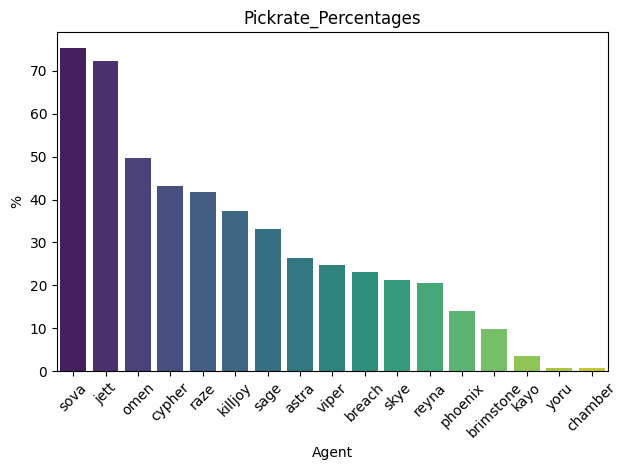

```python
# Plot our agent pickrate percentages with matplotlib
plt.figure()
palette = sns.color_palette("viridis", len(pickrate))
sns.barplot(
    data=pickrate,
    x='Agent',
    y='Pickrate_Percentage',
    order=pickrate.sort_values('Pickrate_Percentage', ascending=False)['Agent'],
    palette=palette
)
plt.title('Pickrate_Percentages')
plt.xlabel('Agent')
plt.ylabel('%')
plt.xticks(rotation=45)
plt.tight_layout()
plt.show()
```

From the plot we see that Sova is our most picked agent, while Chamber, Yoru and Kayo have a pickrate of less than 5%! This shows us what the perceived meta was for this era of Valorant, with the team compositions most likely being, Sova, Jett, Omen, Cypher, and Raze. We can also look at the stats of each agent, similar to what we did in Project Checkpoint #2. If we use the dropna() function to remove any missing values of [Average Combat Score(ACS)](https://dotesports.com/valorant/news/what-is-acs-in-valorant-and-how-is-it-calculated) and RoundHistory, we can average the values for each agent and plot them in order.

```python
# Drop missing values with dropna
game_rounds = game_rounds.dropna(subset=['RoundHistory'])
game_scoreboard_ACS = game_scoreboard.dropna(subset=['ACS'])

# Start by grouping the agents and roles by average ACS
agent_acs = game_scoreboard_ACS.groupby('Agent')['ACS'].mean().reset_index()
agent_acs.columns = ['Agent', 'ACS']
role_acs = game_scoreboard_ACS.groupby('Role')['ACS'].mean().reset_index()
role_acs.columns = ['Role', 'Role_ACS']

# Merge the two dataframes into our stat_info dataframe and remove any duplicates
stat_info = pd.merge(agent_acs, game_scoreboard_ACS[['Agent', 'Role']].drop_duplicates(), on='Agent')
stat_info = pd.merge(stat_info, role_acs, on='Role')
display(stat_info.sort_values(by="ACS", ascending=False))
```

|  | Agent | ACS | Role | Role_ACS |
| --- | --- | --- | --- | --- |
| 10 | raze | 235.210910 | Duelist | 230.667042 |
| 11 | reyna | 230.294592 | Duelist | 230.667042 |
| 5 | jett | 230.045706 | Duelist | 230.667042 |
| 9 | phoenix | 221.685185 | Duelist | 230.667042 |
| 16 | yoru | 213.034483 | Duelist | 230.667042 |
| 3 | chamber | 211.494845 | Sentinel | 191.431349 |
| 7 | killjoy | 198.350604 | Sentinel | 191.431349 |
| 14 | sova | 196.949107 | Initiator | 190.982461 |
| 15 | viper | 194.945048 | Controller | 189.890454 |
| 2 | brimstone | 189.913515 | Controller | 189.890454 |
| 6 | kayo | 188.973832 | Initiator | 190.982461 |
| 8 | omen | 188.651795 | Controller | 189.890454 |
| 12 | sage | 188.386986 | Sentinel | 191.431349 |
| 13 | skye | 188.231286 | Initiator | 190.982461 |
| 0 | astra | 187.482421 | Controller | 189.890454 |
| 4 | cypher | 187.451516 | Sentinel | 191.431349 |
| 1 | breach | 174.445592 | Initiator | 190.982461 |

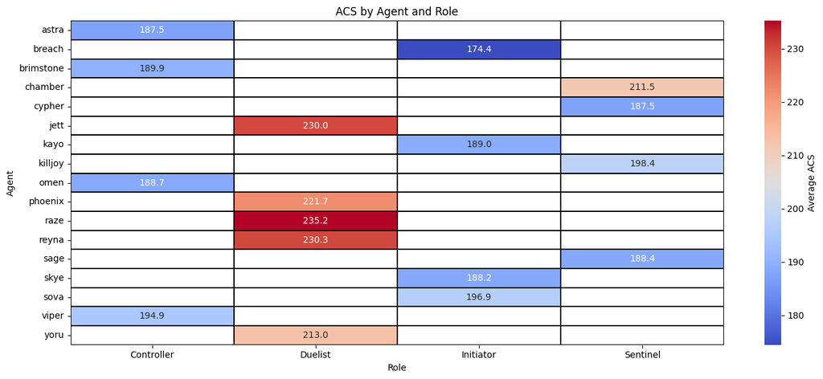

```python
# Using seaborn's heatmap, we can plot the role and agent ACS to compare cross-role and within-role rankings
agent_heatmap = game_scoreboard_ACS.groupby(['Agent', 'Role'])['ACS'].mean().unstack()
plt.figure(figsize=(14, 6))
sns.heatmap(agent_heatmap, annot=True, fmt=".1f", cmap="coolwarm", linewidths=0.1, linecolor='black', cbar_kws={'label': 'Average ACS'})
plt.title('ACS by Agent and Role')
plt.xlabel('Role')
plt.ylabel('Agent')
plt.tight_layout()
plt.show()
```

Looking at our plots, we see Raze and other duelists have the highest ACS. This makes sense as this role in Valorant usually has abilities to aid in getting eliminations and doing damage; both high contributors toward ACS. On the lower end of ACS, we have Breach and a few other Initiators. Usually this role supports the Duelists with utility and is a bit more of a selfless role. With this heatmap, it gives us an understanding that ACS might not be the best metric to include as it depends on the role for the most part. We should stick to the agent selections rather than any in-game metric to determine the role of 'the meta'.

## Primary/Machine Learning Analysis

In this section, we will focus on creating a way to understand the meta, then model machine learning algorithms to predict the outcome of a match based on the agents selected. We can start by grouping our agents selected by the GameID and noting which team won a certain map. This way, we create for ourselves a dataset of features (agents) and target (result). For more information on features and targets in machine learning, [click here](https://medium.com/technology-nineleaps/some-key-machine-learning-definitions-b524eb6cb48).

```python
# Start by grouping each scoreboard by ID and Team Name and keeping Agent column.
df_agents_by_game = game_scoreboard.groupby(['GameID', 'TeamAbbreviation'])['Agent'].apply(list).reset_index()

# Since our data can have values where a team may not have all 5 agents recorded, or record an agent twice, we fill in missing values and cull oversampled results
df_agents_by_game['Agent'] = df_agents_by_game['Agent'].apply(lambda x: x[:5] if len(x) > 5 else x + [None] * (5 - len(x)))
df_agents_by_game[['Player1', 'Player2', 'Player3', 'Player4', 'Player5']] = pd.DataFrame(
    df_agents_by_game['Agent'].tolist(), index=df_agents_by_game.index
)

# We can then drop the padded values and remove our Agent column
df_agents_by_game = df_agents_by_game[df_agents_by_game['Agent'].apply(lambda x: any(a is not None for a in x))]
df_agents_by_game.drop(columns=['Agent'], inplace=True)

# We group by the gameID and team to keep the relevant team information
team1 = df_agents_by_game.groupby('GameID').nth(0).reset_index()
team2 = df_agents_by_game.groupby('GameID').nth(1).reset_index()

team1 = team1.add_prefix('Team1_')
team2 = team2.add_prefix('Team2_')

# Merge the dataframes for each team and drop any missing values.
combined_df = pd.merge(team1, team2, left_on='Team1_GameID', right_on='Team2_GameID').drop(columns=['Team2_GameID', 'Team1_index', 'Team2_index'])
combined_df.rename(columns={'Team1_GameID': 'GameID'}, inplace=True)
combined_df = combined_df.dropna().replace('None', '')
```

```python
combined_df
```

|  | GameID | Team1_TeamAbbreviation | Team1_Player1 | Team1_Player2 | Team1_Player3 | Team1_Player4 | Team1_Player5 | Team2_TeamAbbreviation | Team2_Player1 | Team2_Player2 | Team2_Player3 | Team2_Player4 | Team2_Player5 |
| --- | --- | --- | --- | --- | --- | --- | --- | --- | --- | --- | --- | --- | --- |
| 0 | 10003 | AAA | phoenix | raze | cypher | sova | omen | BRN | reyna | cypher | omen | raze | sova |
| 1 | 10004 | AAA | jett | sova | reyna | cypher | omen | BRN | sova | jett | reyna | killjoy | omen |
| 2 | 10005 | AAA | jett | raze | omen | cypher | breach | BRN | raze | killjoy | omen | breach | jett |
| 3 | 10006 | HSDI | phoenix | omen | sage | viper | raze | MM | phoenix | raze | killjoy | omen | viper |
| 4 | 10007 | HSDI | sage | phoenix | jett | omen | viper | MM | raze | phoenix | killjoy | omen | viper |
| ... | ... | ... | ... | ... | ... | ... | ... | ... | ... | ... | ... | ... | ... |
| 15434 | 9993 | BRN | jett | breach | sova | omen | cypher | MiTH | reyna | jett | cypher | omen | sova |
| 15435 | 9994 | IV | jett | sova | cypher | breach | omen | PRX | phoenix | jett | cypher | sova | omen |
| 15436 | 9995 | IV | raze | breach | jett | killjoy | omen | PRX | jett | omen | sage | raze | cypher |
| 15437 | 9997 | AAA | raze | jett | omen | cypher | breach | ex-F | raze | reyna | omen | cypher | breach |
| 15438 | 9998 | AAA | jett | sova | cypher | omen | breach | ex-F | reyna | cypher | jett | sova | omen |

14236 rows × 13 columns

```python
# Using the RoundHistory column, we can check the last instance of Round winner and define the result of the game from there, since the team that won the last round is the winner.
# We have the match results, but no good way to match TeamAbbr to Team Name.
def round_winner(round_history):
    if isinstance(round_history, str):
        round_history = eval(round_history)
    if isinstance(round_history, dict):
        last_round = max(round_history.keys())
        return round_history[last_round]['RoundWinner']
    return None

game_rounds['Winner'] = game_rounds['RoundHistory'].apply(round_winner)
```

```python
display(game_rounds.head())
```

|  | GameID | Team1ID | Team2ID | RoundHistory | Winner |
| --- | --- | --- | --- | --- | --- |
| 0 | 60894 | 6903 | 6020 | {1: {'RoundWinner': 'BOOS', 'ScoreAfterRound':... | BOOS |
| 1 | 60895 | 6903 | 6020 | {1: {'RoundWinner': 'PHO ', 'ScoreAfterRound':... | PHO |
| 2 | 60896 | 6903 | 6020 | {1: {'RoundWinner': 'PHO ', 'ScoreAfterRound':... | BOOS |
| 3 | 60924 | 7046 | 7047 | {1: {'RoundWinner': 'BJOR', 'ScoreAfterRound':... | BJOR |
| 4 | 60925 | 7046 | 7047 | {1: {'RoundWinner': 'BJOR', 'ScoreAfterRound':... | BJOR |

The RoundHistory tab has the winner of each round within a map. Since one dataframe uses TeamAbbreviation, it makes it difficult to determine the winner of the match without matching the team to its abbreviation. Instead, we can find the last 'roundwinner' in the history column to find out which TeamAbbreviation won.

```python
# We can add a Winner column to our dataframe and check which team won a GameID
combined_df = combined_df.merge(game_rounds[['GameID', 'Winner']], on='GameID', how='left')
combined_df = combined_df.applymap(lambda x: x.lower() if isinstance(x, str) else x)

def determine_winner(row):
    if row['Winner'] == row['Team1_TeamAbbreviation']:
        return 'Team1'
    elif row['Winner'] == row['Team2_TeamAbbreviation']:
        return 'Team2'
    return row['Winner']

combined_df['Winner'] = combined_df.apply(determine_winner, axis=1)
combined_df = combined_df.drop(columns=['GameID', 'Team1_TeamAbbreviation', 'Team2_TeamAbbreviation'])
```

```python
display(combined_df)

# Using the same idea as before, check each team count to make sure we do not have a class imbalance
team1_count = combined_df['Winner'].value_counts().get('Team1', 0)
team2_count = combined_df['Winner'].value_counts().get('Team2', 0)

print(f"Team 1 won {team1_count} times.")
print(f"Team 2 won {team2_count} times.")
```

|  | Team1_Player1 | Team1_Player2 | Team1_Player3 | Team1_Player4 | Team1_Player5 | Team2_Player1 | Team2_Player2 | Team2_Player3 | Team2_Player4 | Team2_Player5 | Winner |
| --- | --- | --- | --- | --- | --- | --- | --- | --- | --- | --- | --- |
| 0 | phoenix | raze | cypher | sova | omen | reyna | cypher | omen | raze | sova | Team1 |
| 1 | jett | sova | reyna | cypher | omen | sova | jett | reyna | killjoy | omen | Team2 |
| 2 | jett | raze | omen | cypher | breach | raze | killjoy | omen | breach | jett | Team1 |
| 3 | phoenix | omen | sage | viper | raze | phoenix | raze | killjoy | omen | viper | Team1 |
| 4 | sage | phoenix | jett | omen | viper | raze | phoenix | killjoy | omen | viper | Team2 |
| ... | ... | ... | ... | ... | ... | ... | ... | ... | ... | ... | ... |
| 14231 | jett | breach | sova | omen | cypher | reyna | jett | cypher | omen | sova | Team2 |
| 14232 | jett | sova | cypher | breach | omen | phoenix | jett | cypher | sova | omen | Team2 |
| 14233 | raze | breach | jett | killjoy | omen | jett | omen | sage | raze | cypher | Team2 |
| 14234 | raze | jett | omen | cypher | breach | raze | reyna | omen | cypher | breach | Team1 |
| 14235 | jett | sova | cypher | omen | breach | reyna | cypher | jett | sova | omen | Team1 |

14236 rows × 11 columns

```
Team 1 won 6789 times.
Team 2 won 6641 times.
```

Now that we have our dataset ready, we can start by building and testing a model. Although we have a fair bit of data, we have a relatively low feature count. Choosing a model that is relatively simple would make the most sense as we do not want to overfit to our data. Starting off with a Logistic Regression model would be the best choice to start with. Logistic regression is less likely to over-fit low dimensional datasets and makes no assumptions about distributions of classes. However, we may run into issues with the linear boundaries it create and may have to shift to using a different model for our next test. For more information on Logistic Regression, [click here](https://www.ibm.com/think/topics/logistic-regression). We will also need to Encode our features with One Hot Encoding. For more information on OneHotEncoding, [click here](https://scikit-learn.org/1.5/modules/generated/sklearn.preprocessing.OneHotEncoder.html).

We can the view the results with a [Confusion Matrix](https://scikit-learn.org/1.5/modules/generated/sklearn.metrics.confusion_matrix.html) and [ROC Curve](https://scikit-learn.org/1.5/modules/generated/sklearn.metrics.roc_curve.html). These, along with the model itself, are provided by [sklearn](https://scikit-learn.org/stable/) and offer a great way to implement and view machine learning models. The confusion matrix will help us understand the relationship between False Positives, True Negatives, etc. The ROC Curve will let us know how good our model is at predicting, with values of around 0.5 indicating it is no better than random choice, and values or 1 indicating perfect predictions.

```
Confusion Matrix:
[[720 632]
 [557 939]]
Classification Report:
              precision    recall  f1-score   support

           0       0.56      0.53      0.55      1352
           1       0.60      0.63      0.61      1496

    accuracy                           0.58      2848
   macro avg       0.58      0.58      0.58      2848
weighted avg       0.58      0.58      0.58      2848
```

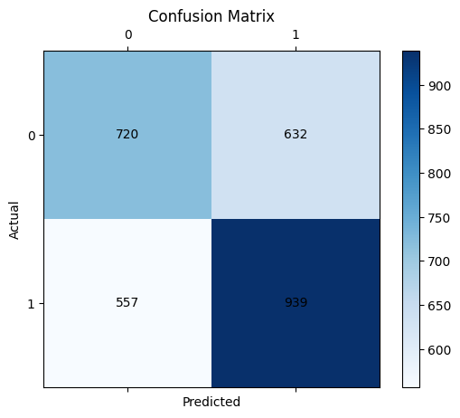

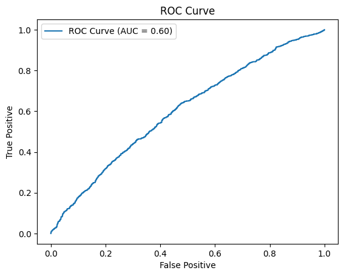

```python
# 10 FEATURES, LOGISTIC REGRESSION

# sklearn has a lot of great tools, we can import what we need for any model we make
from sklearn.linear_model import LogisticRegression
from sklearn.metrics import confusion_matrix, classification_report, roc_curve, auc
from sklearn.model_selection import train_test_split, GridSearchCV
from sklearn.preprocessing import OneHotEncoder
from sklearn.ensemble import RandomForestClassifier
from imblearn.over_sampling import SMOTE

# Set our features to the first 10 columns and the target to the Winner, converting win/loss to 1/0.
features = pd.get_dummies(combined_df.iloc[:, :-1])
target = combined_df['Winner'].apply(lambda x: 0 if x == 'Team1' else 1)

# Since we have categorical features, we can use OneHotEncoding the convert these values
encoder = OneHotEncoder(sparse_output=False)
X_encoded = encoder.fit_transform(features)

# Split the data into training and test with sklearn's train_test_split
X_train, X_test, y_train, y_test = train_test_split(X_encoded, target, test_size=0.2, random_state=42)

# Create a LogisticRegression model and train it on our training data
model = LogisticRegression(max_iter=1000)
model.fit(X_train, y_train)

# Predict the output with out test data
y_pred = model.predict(X_test)
y_prob = model.predict_proba(X_test)[:, 1]

# View the results of our model with a confusion matrix and ROC curve, provided by sklearn
conf_matrix = confusion_matrix(y_test, y_pred)
print("Confusion Matrix:")
print(conf_matrix)

print("Classification Report:")
print(classification_report(y_test, y_pred))

plt.figure()
plt.matshow(conf_matrix, cmap="Blues", fignum=1)
plt.title("Confusion Matrix")
plt.colorbar()
plt.xlabel("Predicted")
plt.ylabel("Actual")

for i in range(conf_matrix.shape[0]):
    for j in range(conf_matrix.shape[1]):
        plt.text(j, i, str(conf_matrix[i, j]), ha='center', va='center', color="black")

plt.show()

fpr, tpr, _ = roc_curve(y_test, y_prob)
roc_auc = auc(fpr, tpr)

plt.figure()
plt.plot(fpr, tpr, label=f"ROC Curve (AUC = {roc_auc:.2f})")
plt.xlabel("False Positive")
plt.ylabel("True Positive")
plt.title("ROC Curve")
plt.legend()
plt.show()
```

Our first model performed pretty poorly, with an Precision, Recall and F1-Score of:

- Class 0: 56% 53% 55%
- Class 1: 60% 63% 61%

And an overall accuracy of 58% and an ROC Curve of 0.6. This leads us to ask, 'are there a lot of duplicate rows?', where teams played the same composition but had different results. We can use the duplicated() function again to check this below:

```python
# Check the number of duplicate rows in our combined dataset.
duplicates_count = combined_df.iloc[:, :-1].duplicated(keep=False).sum()
print(f"Number of duplicate rows: {duplicates_count}")
```

```
Number of duplicate rows: 48
```

We see only 48 rows match this criteria. Since this is the case, it may lead to the answer that 'the meta' does not exist, and team composition is not important to the results of a match. However, we should also test a model that allows non-linear relationships like the Random Forest Classifier. [RandomForestClassifier](https://scikit-learn.org/1.5/modules/generated/sklearn.ensemble.RandomForestClassifier.html). Again, provided by sklearn, this model is robust to overfitting and allows us to have non-linear relationships in our data. This time, we will train the model using something known as [GridSearchCV](https://scikit-learn.org/dev/modules/generated/sklearn.model_selection.GridSearchCV.html). This is another tool from sklearn that allows us to tune the hyperparameter of our model and select the best ones. For more information on what hyperparameters are, [click here](https://aws.amazon.com/what-is/hyperparameter-tuning/).

```
Best Parameters: {'max_depth': None, 'min_samples_leaf': 2, 'min_samples_split': 5, 'n_estimators': 200}
Classification Report:
               precision    recall  f1-score   support

           0       0.54      0.50      0.52      1352
           1       0.58      0.61      0.59      1496

    accuracy                           0.56      2848
   macro avg       0.56      0.56      0.56      2848
weighted avg       0.56      0.56      0.56      2848
```

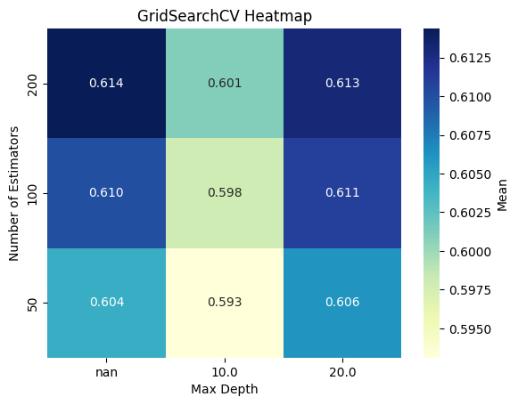

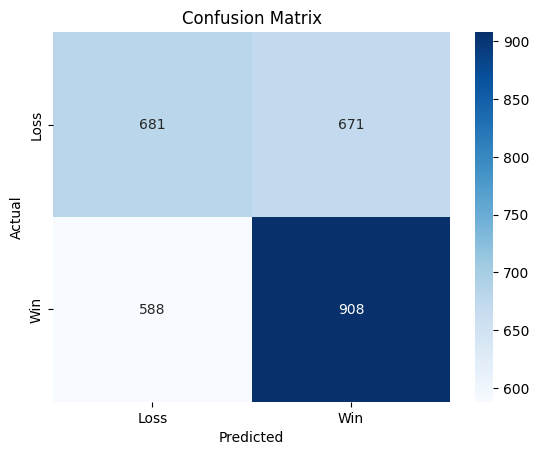

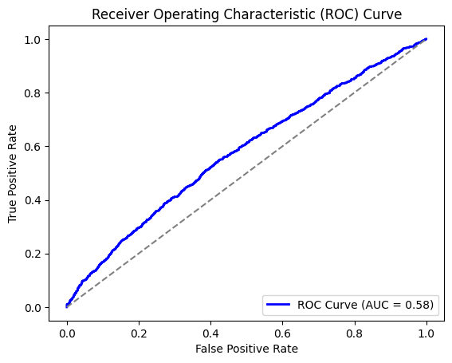

```python
# 10 FEATURES, RANDOMFORESTCLASSIFIER

# We split out data into features and target, with the first 10 rows being the features and Won being the target
features = pd.get_dummies(combined_df.iloc[:, :-1])
target = combined_df['Winner'].apply(lambda x: 0 if x == 'Team1' else 1)

# Encode features
encoder = OneHotEncoder(sparse_output=False, handle_unknown='ignore')  # Use handle_unknown='ignore'
X_train, X_test, y_train, y_test = train_test_split(features, target, test_size=0.2, random_state=42)

# Fit on training data, transform both training and test data
X_train_encoded = encoder.fit_transform(X_train)
X_test_encoded = encoder.transform(X_test)

# Use SMOTE to resample our features and target
smote = SMOTE(random_state=42)
X_train_resampled, y_train_resampled = smote.fit_resample(X_train_encoded, y_train)

# Use GridSearchCV to tune hyperparameters
param_grid = {
    'n_estimators': [50, 100, 200],
    'max_depth': [None, 10, 20],
    'min_samples_split': [2, 5, 10],
    'min_samples_leaf': [1, 2, 4]
}
grid_search = GridSearchCV(RandomForestClassifier(random_state=42), param_grid, cv=3, scoring='roc_auc')
grid_search.fit(X_train_resampled, y_train_resampled)

# Select the best model and print the results
best_model = grid_search.best_estimator_
y_pred = best_model.predict(X_test_encoded)
y_pred_proba = best_model.predict_proba(X_test_encoded)[:, 1]

print("Best Parameters:", grid_search.best_params_)
print("Classification Report:\n", classification_report(y_test, y_pred))

# Create a heatmap of our GridSearchCV results
results = grid_search.cv_results_
param_n_estimators = results['param_n_estimators'].data
param_max_depth = results['param_max_depth'].data
mean_test_score = results['mean_test_score']
heatmap_data = {}
for n_estimator, max_depth, score in zip(param_n_estimators, param_max_depth, mean_test_score):
    if max_depth not in heatmap_data:
        heatmap_data[max_depth] = {}
    heatmap_data[max_depth][n_estimator] = score
heatmap_df = pd.DataFrame(heatmap_data).sort_index(ascending=False)

# Use seaborn to plot the Heatmap
plt.figure()
sns.heatmap(heatmap_df, annot=True, cmap="YlGnBu", cbar_kws={'label': 'Mean'}, fmt=".3f")
plt.xlabel("Max Depth")
plt.ylabel("Number of Estimators")
plt.title("GridSearchCV Heatmap")
plt.show()

# As we did before, we can plot our confusion matrix and ROC Curse
conf_matrix = confusion_matrix(y_test, y_pred)

plt.figure()
sns.heatmap(conf_matrix, annot=True, fmt="d", cmap="Blues", xticklabels=["Loss", "Win"], yticklabels=["Loss", "Win"])
plt.xlabel("Predicted")
plt.ylabel("Actual")
plt.title("Confusion Matrix")
plt.show()

fpr, tpr, thresholds = roc_curve(y_test, y_pred_proba)
roc_auc = auc(fpr, tpr)

plt.figure()
plt.plot(fpr, tpr, color='blue', lw=2, label=f"ROC Curve (AUC = {roc_auc:.2f})")
plt.plot([0, 1], [0, 1], color='grey', linestyle='--')
plt.xlabel("False Positive Rate")
plt.ylabel("True Positive Rate")
plt.title("Receiver Operating Characteristic (ROC) Curve")
plt.legend(loc="lower right")
plt.show()
```

Surprisingly, we see a drop in performance when using the Random Forest. Looking at our hyperparameters, it seems to favors a more complex model or larger tree. Our confusion matrix also tells us that we have a high False Positive Rate, were the model is incorrectly predicting the correct class. Let's try changing our dataset a bit to include only the 5 agents on a team. This may help since there could be mirrored agents (duplicate features) from the dataset, and also is more practical when it comes to use, as Valorant does not show the enemy team composition before a game.

## Secondary/Machine Learning Analysis

We will start the same way we did last time, by grouping our agents by the game and adding a Won/Lost column to indicate the map results.

```python
# As we did with our last model, we will group agents by game and fix any missing or oversampled agents
df_agents_by_game = game_scoreboard.groupby(['GameID', 'TeamAbbreviation'])['Agent'].apply(list).reset_index()
df_agents_by_game['Agent'] = df_agents_by_game['Agent'].apply(lambda x: x[:5] if len(x) > 5 else x + [None] * (5 - len(x)))
df_agents_by_game[['Player1', 'Player2', 'Player3', 'Player4', 'Player5']] = pd.DataFrame(
    df_agents_by_game['Agent'].tolist(), index=df_agents_by_game.index
)

df_agents_by_game = df_agents_by_game[df_agents_by_game['Agent'].apply(lambda x: any(a is not None for a in x))]
df_agents_by_game.drop(columns=['Agent'], inplace=True)
```

```python
# We can merge the winner column we have and determine if a team Won or Lost
df_agents_by_game = df_agents_by_game.merge(
    game_rounds[['GameID', 'Winner']],
    on='GameID',
    how='left'
)
df_agents_by_game['Won'] = (df_agents_by_game['TeamAbbreviation'] == df_agents_by_game['Winner']).astype(int)
df_agents_by_game = df_agents_by_game.drop(columns=['GameID', 'TeamAbbreviation', 'Winner'])
df_agents_by_game = df_agents_by_game.dropna().replace('None', '')
df_agents_by_game
```

|  | Player1 | Player2 | Player3 | Player4 | Player5 | Won |
| --- | --- | --- | --- | --- | --- | --- |
| 0 | phoenix | raze | cypher | sova | omen | 1 |
| 1 | reyna | cypher | omen | raze | sova | 0 |
| 2 | jett | sova | reyna | cypher | omen | 0 |
| 3 | sova | jett | reyna | killjoy | omen | 1 |
| 4 | jett | raze | omen | cypher | breach | 1 |
| ... | ... | ... | ... | ... | ... | ... |
| 31941 | jett | omen | sage | raze | cypher | 1 |
| 31942 | raze | jett | omen | cypher | breach | 1 |
| 31943 | raze | reyna | omen | cypher | breach | 0 |
| 31944 | jett | sova | cypher | omen | breach | 1 |
| 31945 | reyna | cypher | jett | sova | omen | 0 |

29558 rows × 6 columns

```python
# view our class imbalance and check if we need to account for this in the model.
count_won_zero = (df_agents_by_game['Won'] == 0).sum()
count_won_zero
```

```
17978
```

Now that we have our new dataset, we can input these features into our X and y (features and targets) variables, then encode our features so the model can use them. Although RandomForestClassifiers can handle categorical variables, this implementation still requires we change them. We also use something known as GridSearchCV, which we mentioned before. This allows us to test different combinations of hyperparameters and view a heatmap of the results of each.

Also, although our class imbalance is not terrible, we can use SMOTE to help balance our dataset before training. For more information on what SMOTE is and how to use it, [click here](https://machinelearningmastery.com/smote-oversampling-for-imbalanced-classification/).

```python
# 5 FEATURES, RANDOMFORESTCLASSIFIER

# We split out data into features and target, with the first five rows being the features and Won being the target
X = df_agents_by_game[['Player1', 'Player2', 'Player3', 'Player4', 'Player5']]
y = df_agents_by_game['Won']

# Although we are using a RandomForest, which can handle categorical features, this implementation requires us to use this
encoder = OneHotEncoder(sparse_output=False)
X_encoded = encoder.fit_transform(X)

# Split the data
X_train, X_test, y_train, y_test = train_test_split(X_encoded, y, test_size=0.2, random_state=42)

# Using SMOTE, we can account for any class imbalance, as there are a wide variety of agent combos we should account for
smote = SMOTE(random_state=42)
X_train_resampled, y_train_resampled = smote.fit_resample(X_train, y_train)

# GridSearchCV allows us to get the best hyperparameters for our model by testing each combination.
param_grid = {
    'n_estimators': [50, 100, 200],
    'max_depth': [None, 10, 20],
    'min_samples_split': [2, 5, 10],
    'min_samples_leaf': [1, 2, 4]
}

grid_search = GridSearchCV(RandomForestClassifier(random_state=42), param_grid, cv=3, scoring='roc_auc')
grid_search.fit(X_train_resampled, y_train_resampled)

# we choose the best model and predict results, we can display the accuracy, ROC, and Classification Report again
best_model = grid_search.best_estimator_

y_pred = best_model.predict(X_test)
y_pred_proba = best_model.predict_proba(X_test)[:, 1]

print("Best Parameters:", grid_search.best_params_)
print("Classification Report:\n", classification_report(y_test, y_pred))
```

```
Best Parameters: {'max_depth': 20, 'min_samples_leaf': 1, 'min_samples_split': 2, 'n_estimators': 200}
Classification Report:
               precision    recall  f1-score   support

           0       0.63      0.65      0.64      3543
           1       0.44      0.42      0.43      2369

    accuracy                           0.56      5912
   macro avg       0.53      0.53      0.53      5912
weighted avg       0.55      0.56      0.55      5912
```

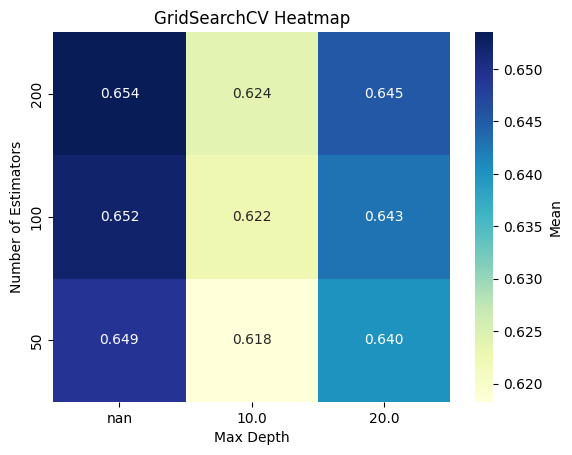

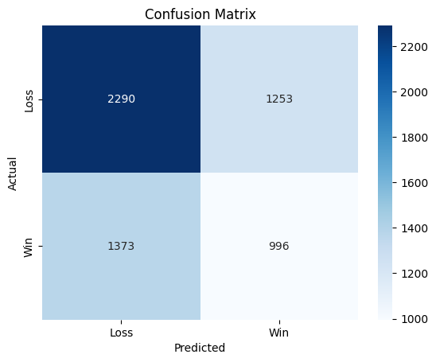

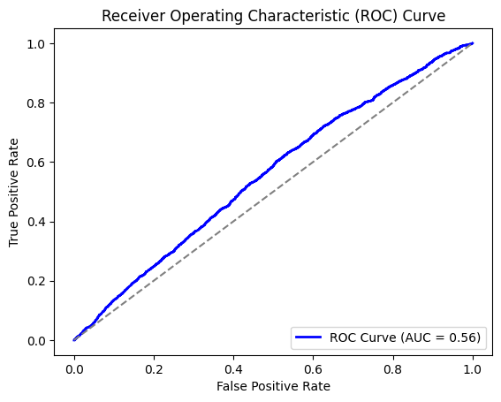

```python
# Create a heatmap of our GridSearchCV results
results = grid_search.cv_results_
param_n_estimators = results['param_n_estimators'].data
param_max_depth = results['param_max_depth'].data
mean_test_score = results['mean_test_score']
heatmap_data = {}
for n_estimator, max_depth, score in zip(param_n_estimators, param_max_depth, mean_test_score):
    if max_depth not in heatmap_data:
        heatmap_data[max_depth] = {}
    heatmap_data[max_depth][n_estimator] = score
heatmap_df = pd.DataFrame(heatmap_data).sort_index(ascending=False)

# Use seaborn to plot the Heatmap
plt.figure()
sns.heatmap(heatmap_df, annot=True, cmap="YlGnBu", cbar_kws={'label': 'Mean'}, fmt=".3f")
plt.xlabel("Max Depth")
plt.ylabel("Number of Estimators")
plt.title("GridSearchCV Heatmap")
plt.show()

# As we did before, we can plot our confusion matrix and ROC Curse
conf_matrix = confusion_matrix(y_test, y_pred)

plt.figure()
sns.heatmap(conf_matrix, annot=True, fmt="d", cmap="Blues", xticklabels=["Loss", "Win"], yticklabels=["Loss", "Win"])
plt.xlabel("Predicted")
plt.ylabel("Actual")
plt.title("Confusion Matrix")
plt.show()

fpr, tpr, thresholds = roc_curve(y_test, y_pred_proba)
roc_auc = auc(fpr, tpr)

plt.figure()
plt.plot(fpr, tpr, color='blue', lw=2, label=f"ROC Curve (AUC = {roc_auc:.2f})")
plt.plot([0, 1], [0, 1], color='grey', linestyle='--')
plt.xlabel("False Positive Rate")
plt.ylabel("True Positive Rate")
plt.title("Receiver Operating Characteristic (ROC) Curve")
plt.legend(loc="lower right")
plt.show()
```

We can also try our Logistic Regression model on this new dataset to see if there is an improvement.

```
Confusion Matrix:
[[1759 1784]
 [ 953 1416]]
Classification Report:
              precision    recall  f1-score   support

           0       0.65      0.50      0.56      3543
           1       0.44      0.60      0.51      2369

    accuracy                           0.54      5912
   macro avg       0.55      0.55      0.54      5912
weighted avg       0.57      0.54      0.54      5912
```

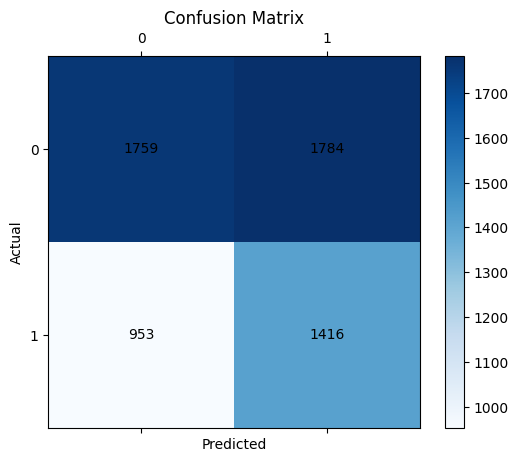

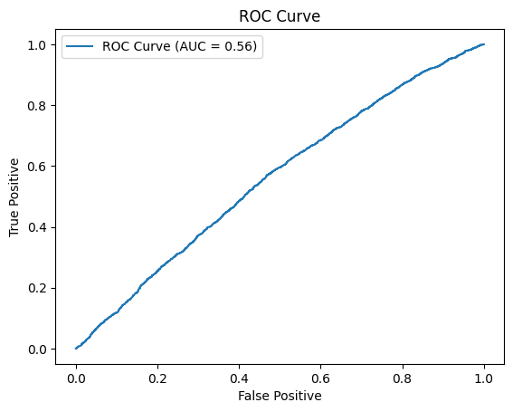

```python
# 5 FEATURES, LOGISTIC REGRESSION

# Split the data into X and y, feature and target
X = df_agents_by_game[['Player1', 'Player2', 'Player3', 'Player4', 'Player5']]
y = df_agents_by_game['Won']

# Encode our features
encoder = OneHotEncoder(sparse_output=False)
X_encoded = encoder.fit_transform(X)

# Split the data
X_train, X_test, y_train, y_test = train_test_split(X_encoded, y, test_size=0.2, random_state=42)

# Using SMOTE, we can account for any class imbalance
smote = SMOTE(random_state=42)
X_train_resampled, y_train_resampled = smote.fit_resample(X_train, y_train)

# Create a LogisticRegression model and train it on our training data
model = LogisticRegression(max_iter=1000)
model.fit(X_train_resampled, y_train_resampled)

# Predict the output with out test data
y_pred = model.predict(X_test)
y_prob = model.predict_proba(X_test)[:, 1]

# View the results of our model with a confusion matrix and ROC curve, provided by sklearn
conf_matrix = confusion_matrix(y_test, y_pred)
print("Confusion Matrix:")
print(conf_matrix)

print("Classification Report:")
print(classification_report(y_test, y_pred))

plt.figure()
plt.matshow(conf_matrix, cmap="Blues", fignum=1)
plt.title("Confusion Matrix")
plt.colorbar()
plt.xlabel("Predicted")
plt.ylabel("Actual")

for i in range(conf_matrix.shape[0]):
    for j in range(conf_matrix.shape[1]):
        plt.text(j, i, str(conf_matrix[i, j]), ha='center', va='center', color="black")

plt.show()

fpr, tpr, _ = roc_curve(y_test, y_prob)
roc_auc = auc(fpr, tpr)

plt.figure()
plt.plot(fpr, tpr, label=f"ROC Curve (AUC = {roc_auc:.2f})")
plt.xlabel("False Positive")
plt.ylabel("True Positive")
plt.title("ROC Curve")
plt.legend()
plt.show()
```

After viewing the results, we see a similar performance. This model struggles to predict the correct class and identify the best team composition. From the 4 types of models we tested, our model that used 10 features and Logistic Regression performed the 'best'. This leads us into our final section and prepares us to answer our original question of what is meta, and does it exist.

## Conclusion

From our 4 types of models, we found that it is difficult to predict the winner of a map based on the agents selected. While it may be easy to say this is conclusive evidence toward 'the meta' not existing, there are some caveats we need to account for. For example, since there is a perception of what is 'meta', players tend to pick similar compositions. This makes it difficult to test every possible combination of agents and truly determine which is the best. However, whatever the case may be, to answer our original question, 'what is meta, and does it exist', we can say that for this era of Valorant and with this dataset, there does not seem to be a dominant composition or agent required to win a match. The best option would be to mirror the enemy team composition or simply pick the agents with the highest pickrate for their respective roles.

Thank you for taking the time to read through this machine learning and data science tutorial. I hope it shed light onto the process of both and showed the importance of constant interaction and back-and-forth between steps in the 'pipeline'. If you want to learn more about Valorant or continue this project on your own, click here.